# VariantBench — Metabolic-Trait GWAS Follow-up (LDL_C, BCAA, Glucose, Lactate; EUR)

Khushi Goda

2026-07-26

# 1 Overview & method choices

> **Reproducibility.** This document is the R Markdown source `workflow/scripts/08_report.Rmd`, knitted by the Snakemake `report` rule. Every number, table, and figure below is generated at knit time by reading the pipeline’s output files in `results/` — nothing is hand-entered or pasted. Re-running the pipeline and re-knitting regenerates this report end to end, so the report cannot drift from the analysis it describes.

This report follows four circulating metabolic traits — **LDL cholesterol (LDL_C)**, **total branched-chain amino acids (BCAA)**, **glucose**, and **lactate** — from published GWAS summary statistics through a standard post-GWAS causal-inference chain: cross-cohort meta-analysis, heritability and genetic correlation (LDSC), lead-variant definition, statistical fine-mapping, colocalization with gene expression, and Mendelian randomization against two cardiometabolic diseases. The analysis is **European-ancestry throughout** (EstBB + UKBB_EUR exposures, EUR-matched CAD/T2D outcomes, 1000G EUR LD reference), and **no individual-level genotype data is used** — every step operates on summary statistics plus a public LD reference.

The four exposures are chosen as a **gradient of causal-prior strength**, so the pipeline is shown to *discriminate* rather than merely run. **LDL_C is the canonical positive control**: the causal LDL→CAD relationship is proven by RCTs of statins (*HMGCR*), PCSK9 inhibitors (*PCSK9*), and ezetimibe (*NPC1L1*), so recovering a positive *cis*-MR at these drug-target genes is the strongest validation of the whole arc. **BCAA** (anchored by the catabolic regulators *PPM1K* / *BCKDK*) and **glucose** (anchored by *GCK* / *GCKR* / *G6PC2* / *SLC30A8*) are further positive controls for the diabetes axis, both tested against T2D. **Lactate is the contrast**: different biology (glycolysis), a weaker causal prior, and a notable locus at *GP6* (platelet collagen receptor) biologically distant from a metabolic-disease mechanism — a test of whether the methods correctly report a *less* compelling causal picture. Four exposures across four chromosomes and pathways demonstrate that the pipeline **discriminates** strong causal signals from weak ones.

**Method choice stated up front — the LD reference is out-of-sample.** Fine-mapping, clumping, and MR instrument pruning use a 1000 Genomes EUR panel, **not** the in-sample UKBB LD the reference paper used. Out-of-sample LD can miscalibrate SuSiE credible sets and mis-prune instruments; this is an accepted tractability tradeoff, flagged here and again in each affected section. A second deliberate choice concerns the CAD outcome: the paper’s Methods cite the multi-ancestry `GCST90132315`, but the authors’ released code uses the European-only `GCST90132314`. I use the European-only accession — it keeps exposure and outcome ancestry-matched and avoids a known source of two-sample MR bias, and it is the choice the authors’ own code made. (The multi-ancestry study is not used: with EUR-only exposures it would reintroduce the ancestry mismatch this design is built to avoid.) The CAD file is the GWAS Catalog harmonised (GRCh38) release, matching the GRCh38 metabolite exposures, so no CAD liftover is required; T2D (DIAGRAM, GRCh37) is lifted to GRCh38 in Step 0.

# 2 Meta-analysis (Step 1)

*Inverse-variance fixed-effect meta-analysis of EstBB + UKBB (EUR), genome-wide (every union variant kept, not HapMap3-restricted). Validation: my meta effect sizes are regressed against the authors’ published meta-analysis — the OLS slope and Pearson r should both be ≈1 if the allele harmonization and inverse-variance weighting are correct.*

| metab | pearson_r | slope | n_variants | n_compared | n_both | n_estbb_only | n_ukbb_only |
| --- | --- | --- | --- | --- | --- | --- | --- |
| BCAA | 0.999999999999989 | 0.999999999987551 | 103927003 | 103927003 | 17976457 | 8197137 | 77753409 |
| Lactate | 0.999999999999991 | 1.00000000001978 | 103927003 | 103927003 | 17976457 | 8197137 | 77753409 |
| LDL_C | 0.999999999999986 | 1.00000000002351 | 103927003 | 103927003 | 17976457 | 8197137 | 77753409 |
| Glucose | 1 | 1.00000000000254 | 103927003 | 103927003 | 17976457 | 8197137 | 77753409 |

The validation table is the decisive check on the whole meta step: `pearson_r` and `slope` at machine precision to 1 mean the from-scratch inverse-variance meta reproduces the authors’ published meta exactly, over all union variants. The overlap columns (`n_both`, `n_estbb_only`, `n_ukbb_only`) show that the meta genuinely combined both cohorts rather than defaulting to whichever one was present. This validates that the pre-processing of GWAS summary statistics downloaded were accurate and the dataset for for subsequent downstream analysis was ready.

**Validation — our meta vs the authors’ published `meta_EUR` (per metabolite):**

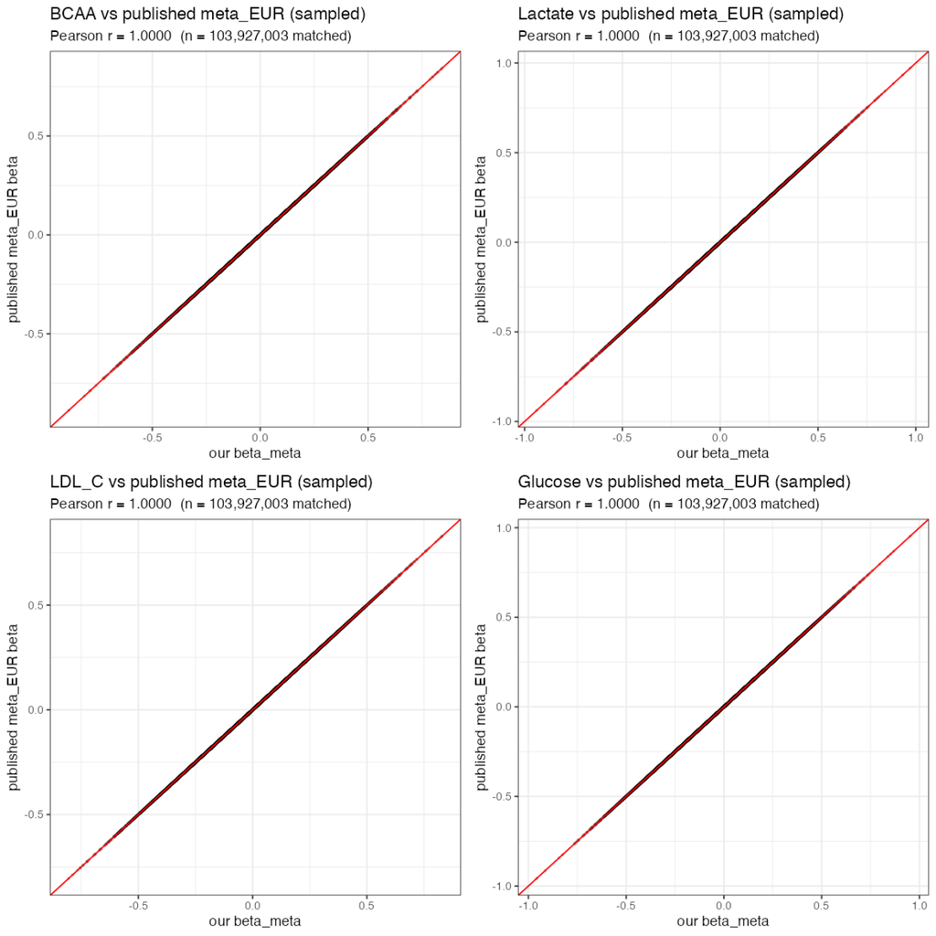

**Cross-cohort concordance — EstBB vs UKBB effect sizes (per metabolite):**

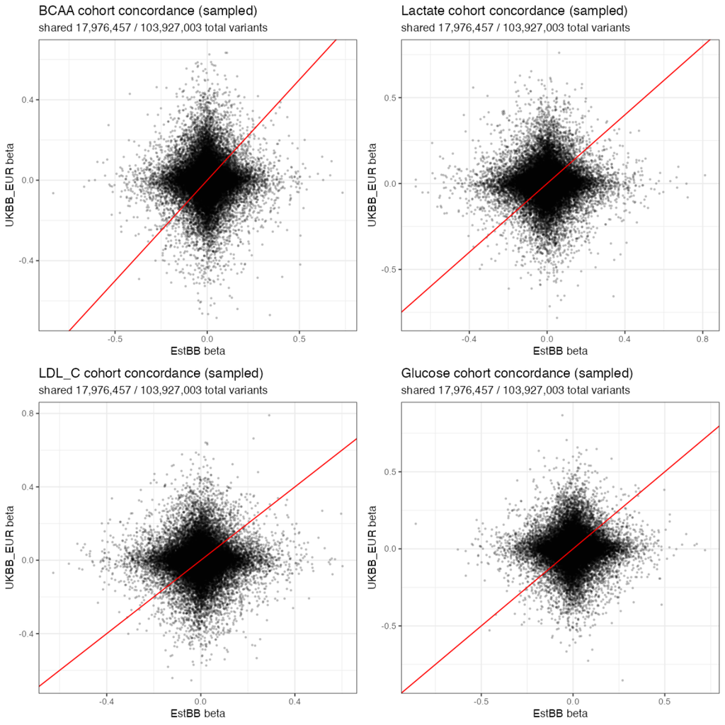

## 2.1 MCQ — Meta-analysis

**A variant is genome-wide significant in the EstBB + UKBB meta-analysis but reached significance in neither cohort alone. The most appropriate interpretation is:**

- A. The meta-analysis has inflated type-I error, so the hit is probably false.
- B. Increased sample size raised power; concordant same-direction effects combined to cross the threshold.
- C. The variant must have opposite effects in the two cohorts.
- D. It indicates a batch effect between cohorts.

*Answer: **B.** Meta-analysis gains power precisely when per-cohort effects are concordant; a sub-threshold-but-consistent signal crossing genome-wide significance is the expected behaviour, not an artifact.*

# 3 Heritability & genetic correlation (Step 2, LDSC)

*SNP-heritability per (trait, dataset) and the paper’s two genetic-correlation analyses — **A**: rg between the three datasets (EstBB, UKBB_EUR, meta_EUR) for each trait; **B**: rg between the four traits within each dataset. The **LDSC intercept** is the key diagnostic: an intercept ≈1 means test-statistic inflation reflects polygenic signal, not population stratification or cryptic relatedness.*

| trait | dataset | h2 | h2_se | intercept |
| --- | --- | --- | --- | --- |
| BCAA | EstBB | 0.0634 | 0.0063 | 1.0268 |
| BCAA | UKBB_EUR | 0.0761 | 0.0065 | 1.0639 |
| BCAA | meta_EUR | 0.0652 | 0.0052 | 1.0808 |
| Lactate | EstBB | 0.0277 | 0.0036 | 1.073 |
| Lactate | UKBB_EUR | 0.0473 | 0.0033 | 1.0619 |
| Lactate | meta_EUR | 0.0389 | 0.0028 | 1.0785 |
| LDL_C | EstBB | 0.1617 | 0.0266 | 1.1416 |
| LDL_C | UKBB_EUR | 0.1105 | 0.0188 | 1.0878 |
| LDL_C | meta_EUR | 0.1175 | 0.0197 | 1.1555 |
| Glucose | EstBB | 0.0343 | 0.0044 | 1.0424 |

[output cut: 2 more lines]

| p1 | p2 | rg | se | z | p | h2_obs | h2_obs_se | h2_int | h2_int_se | gcov_int | gcov_int_se | trait | ds1 | ds2 |
| --- | --- | --- | --- | --- | --- | --- | --- | --- | --- | --- | --- | --- | --- | --- |
| BCAA.EstBB | BCAA.UKBB_EUR | 0.8332 | 0.0287 | 28.9917 | 8.3614e-185 | 0.077 | 0.0066 | 1.0596 | 0.0214 | 0.0218 | 0.0118 | BCAA | EstBB | UKBB_EUR |
| BCAA.EstBB | BCAA.meta_EUR | 0.918 | 0.0153 | 60.1022 | 0 | 0.066 | 0.0054 | 1.0763 | 0.0259 | 0.5892 | 0.0139 | BCAA | EstBB | meta_EUR |
| BCAA.UKBB_EUR | BCAA.meta_EUR | 0.971 | 0.0037 | 260.3238 | 0 | 0.0669 | 0.0055 | 1.0673 | 0.0211 | 0.8997 | 0.019 | BCAA | UKBB_EUR | meta_EUR |
| Lactate.EstBB | Lactate.UKBB_EUR | 0.8641 | 0.06 | 14.4122 | 4.3392e-47 | 0.0455 | 0.004 | 1.075 | 0.0227 | 0.0235 | 0.0134 | Lactate | EstBB | UKBB_EUR |
| Lactate.EstBB | Lactate.meta_EUR | 0.9402 | 0.0342 | 27.5195 | 1.027e-166 | 0.0371 | 0.0031 | 1.0967 | 0.0289 | 0.6169 | 0.0157 | Lactate | EstBB | meta_EUR |
| Lactate.UKBB_EUR | Lactate.meta_EUR | 0.966 | 0.0049 | 198.0364 | 0 | 0.0376 | 0.0029 | 1.0912 | 0.0249 | 0.9096 | 0.0214 | Lactate | UKBB_EUR | meta_EUR |
| LDL_C.EstBB | LDL_C.UKBB_EUR | 0.8531 | 0.0463 | 18.4302 | 7.5176e-76 | 0.0673 | 0.0307 | 1.3432 | 0.2628 | 0.2637 | 0.2134 | LDL_C | EstBB | UKBB_EUR |
| LDL_C.EstBB | LDL_C.meta_EUR | 0.9503 | 0.0155 | 61.3177 | 0 | 0.0777 | 0.0274 | 1.4734 | 0.3345 | 0.957 | 0.2552 | LDL_C | EstBB | meta_EUR |
| LDL_C.UKBB_EUR | LDL_C.meta_EUR | 0.9668 | 0.0071 | 136.6756 | 0 | 0.0813 | 0.0257 | 1.4328 | 0.3088 | 1.1701 | 0.2693 | LDL_C | UKBB_EUR | meta_EUR |
| Glucose.EstBB | Glucose.UKBB_EUR | 0.8971 | 0.0491 | 18.2895 | 1.0029e-74 | 0.0615 | 0.0086 | 1.0808 | 0.0238 | 0.0203 | 0.014 | Glucose | EstBB | UKBB_EUR |

[output cut: 2 more lines]

| p1 | p2 | rg | se | z | p | h2_obs | h2_obs_se | h2_int | h2_int_se | gcov_int | gcov_int_se | dataset | tr1 | tr2 |
| --- | --- | --- | --- | --- | --- | --- | --- | --- | --- | --- | --- | --- | --- | --- |
| BCAA.EstBB | Lactate.EstBB | 0.2635 | 0.0636 | 4.1455 | 3.391e-05 | 0.0264 | 0.0038 | 1.0774 | 0.0109 | 0.1634 | 0.006 | EstBB | BCAA | Lactate |
| BCAA.EstBB | LDL_C.EstBB | 0.1957 | 0.0688 | 2.8445 | 0.0044481 | 0.0942 | 0.0511 | 1.3358 | 0.2096 | 0.1109 | 0.0092 | EstBB | BCAA | LDL_C |
| BCAA.EstBB | Glucose.EstBB | 0.2236 | 0.0592 | 3.7755 | 0.00015968 | 0.0339 | 0.0054 | 1.0438 | 0.0099 | 0.0665 | 0.006 | EstBB | BCAA | Glucose |
| Lactate.EstBB | LDL_C.EstBB | 0.1195 | 0.071 | 1.6831 | 0.0924 | 0.0942 | 0.0511 | 1.3358 | 0.2096 | 0.0993 | 0.0082 | EstBB | Lactate | LDL_C |
| Lactate.EstBB | Glucose.EstBB | -0.2087 | 0.0829 | -2.5169 | 0.0118 | 0.0339 | 0.0054 | 1.0438 | 0.0099 | -0.507 | 0.0088 | EstBB | Lactate | Glucose |
| LDL_C.EstBB | Glucose.EstBB | 0.1958 | 0.0828 | 2.3637 | 0.0181 | 0.0339 | 0.0054 | 1.0438 | 0.0099 | 0.0278 | 0.0084 | EstBB | LDL_C | Glucose |
| BCAA.UKBB_EUR | Lactate.UKBB_EUR | 0.1893 | 0.0363 | 5.2105 | 1.8832e-07 | 0.046 | 0.0037 | 1.0699 | 0.0192 | 0.1141 | 0.008 | UKBB_EUR | BCAA | Lactate |
| BCAA.UKBB_EUR | LDL_C.UKBB_EUR | 0.0488 | 0.0514 | 0.9507 | 0.34177 | 0.0704 | 0.029 | 1.3172 | 0.2439 | 0.101 | 0.0205 | UKBB_EUR | BCAA | LDL_C |
| BCAA.UKBB_EUR | Glucose.UKBB_EUR | 0.2313 | 0.0297 | 7.7755 | 7.5142e-15 | 0.0624 | 0.0082 | 1.0744 | 0.0217 | 0.2494 | 0.0073 | UKBB_EUR | BCAA | Glucose |
| Lactate.UKBB_EUR | LDL_C.UKBB_EUR | 0.0536 | 0.0551 | 0.9732 | 0.33044 | 0.0704 | 0.029 | 1.3172 | 0.2439 | 0.0854 | 0.0166 | UKBB_EUR | Lactate | LDL_C |

[output cut: 8 more lines]

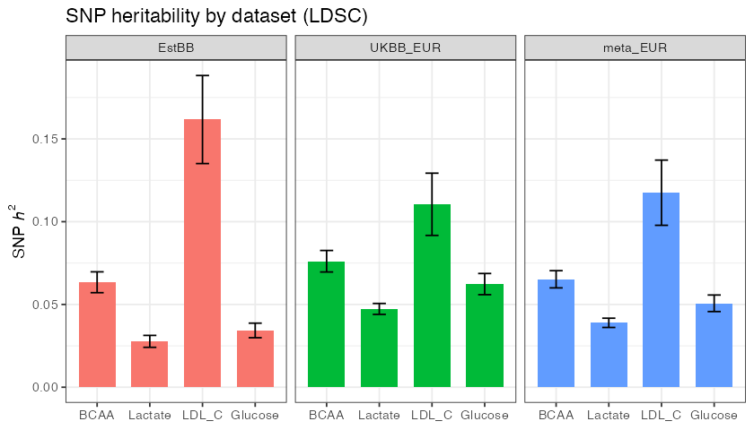

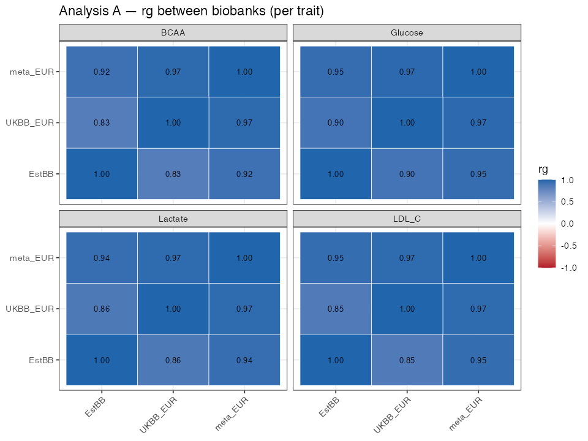

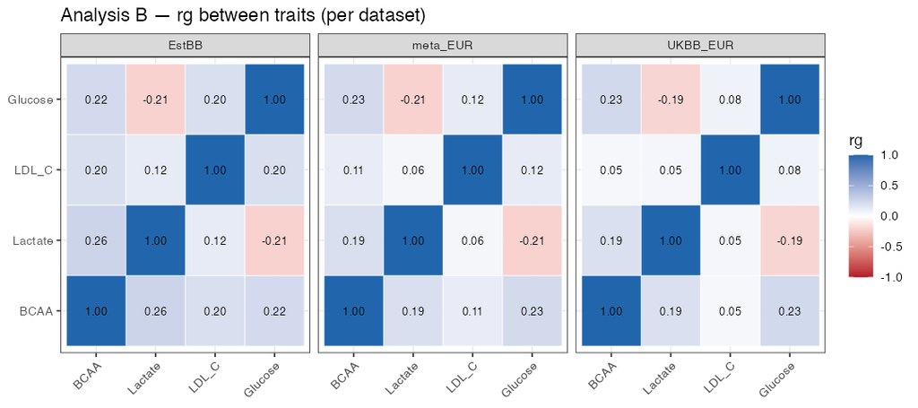

## 3.1 MCQ — Heritability (LDSC)

**The LDSC regression for a trait returns an intercept ≈ 1.0. This indicates:**

- A. Severe population stratification inflating all test statistics.
- B. Minimal confounding; inflation in the test statistics reflects genuine polygenic signal.
- C. The heritability estimate is invalid.
- D. Severe sample overlap between the two cohorts.

*Answer: **B.** The LDSC intercept isolates confounding/inflation from polygenicity; an intercept near 1 means the elevated χ² comes from real polygenic signal, validating the h² estimate. (A markedly elevated intercept would instead flag stratification or sample overlap.)*

# 4 Lead variants (Step 3)

*Genome-wide-significant loci reduced to independent lead variants. Two design choices define this step:*

*1. **Frequency-dependent significance.** Common/low-frequency variants (MAF > 0.1%) use the standard genome-wide line P < 5e-8; rare variants (MAF < 0.1%) use a stricter Bonferroni line P < 0.05/8e7 = 6.25e-10, because the ~80M rare tests make 5e-8 anti-conservative. Variants whose effect-allele frequency is unknown fall back to the standard line and are flagged `maf_class = "unknown"` so the reader can weight them accordingly.*

*2. **Distance-based locus definition.** The most-significant unclaimed variant is taken as a lead, a 2 Mb locus (±1 Mb) is claimed around it, all variants inside are removed, and the process iterates. The brief’s Step 3 is summary-statistics-only and provides no genotype panel, so pairwise r² is not computable; the distance rule is the standard, honest substitute. The paper’s additional r²≥0.05 locus-merge (which stops an ultra-strong signal from “bleeding” past the 2 Mb window) and r²≥0.8 cross-trait clustering require a EUR genotype panel and are deferred to the LD-aware follow-on (Step 4 sourcing).*

| SNP | chr | pos | ea | oa | eaf | maf | maf_class | beta | se | z | pval | neg_log10p | n | direction | het_p | n_cohorts | locus_start | locus_end | n_sig_in_locus | source_file |
| --- | --- | --- | --- | --- | --- | --- | --- | --- | --- | --- | --- | --- | --- | --- | --- | --- | --- | --- | --- | --- |
| rs17035646 | 1 | 10736490 | A | G | 0.362260864970989 | 0.362260864970989 | common | -0.0128553853373458 | 0.00174445546054194 | -7.36928263754702 | 1.71548618292117e-13 | 12.7656127755415 | 599249 | -- | 0.278996096534152 | 2 | 9736490 | 11736490 | 15 | LDL_C.lead.tsv |
| rs10907282 | 1 | 16183644 | G | A | 0.640909577606304 | 0.359090422393696 | common | 0.0137905583022877 | 0.00174786816750278 | 7.88993046425841 | 3.02354957003783e-15 | 14.5194829068935 | 599249 | ++ | 0.400362762699634 | 2 | 15183644 | 17183644 | 94 | LDL_C.lead.tsv |
| rs10917383 | 1 | 23462501 | G | A | 0.875165450587318 | 0.124834549412682 | common | 0.0198033894847423 | 0.00252899944131541 | 7.83052347154412 | 4.858428218022591e-15 | 14.3135042094715 | 599249 | ++ | 0.548404831728484 | 2 | 22462501 | 24462501 | 66 | LDL_C.lead.tsv |
| rs11802413 | 1 | 25434429 | T | C | 0.555077642432445 | 0.444922357567555 | common | 0.0266000228705563 | 0.00168026244178149 | 15.8308739213106 | 1.90556033055431e-56 | 55.7199772967937 | 599249 | ++ | 0.264953216962982 | 2 | 24434429 | 26434429 | 253 | LDL_C.lead.tsv |
| rs114165349 | 1 | 26695422 | C | G | 0.0270055331620078 | 0.0270055331620078 | common | 0.0710595168787969 | 0.00513802819079599 | 13.830114246179 | 1.67753874732748e-43 | 42.7753274398289 | 599249 | ++ | 0.000459164298804166 | 2 | 25695422 | 27695422 | 242 | LDL_C.lead.tsv |
| rs60351648 | 1 | 38980726 | T | TTTTTC | 0.110087710270188 | 0.110087710270188 | common | 0.0155056263705386 | 0.00266419110933715 | 5.82001280471067 | 5.884311930113261e-09 | 8.23030431318172 | 599249 | ++ | 0.792743098697393 | 2 | 37980726 | 39980726 | 18 | LDL_C.lead.tsv |
| rs12407290 | 1 | 44809667 | G | C | 0.164355486100102 | 0.164355486100102 | common | 0.0146421121395105 | 0.00226556770382565 | 6.4628888003593 | 1.02722780718072e-10 | 9.98833323271205 | 599249 | ++ | 0.910717546361725 | 2 | 43809667 | 45809667 | 120 | LDL_C.lead.tsv |
| rs1264731440 | 1 | 48850184 | C | T | 0.000161705 | 0.000161705 | rare | -0.517003 | 0.0827818 | -6.24537035918523 | 4.22797087107751e-10 | 9.37386801345872 | 413897 | ?- |  | 1 | 47850184 | 49850184 | 1 | LDL_C.lead.tsv |
| rs536731403 | 1 | 50914981 | G | C | 0.000159863 | 0.000159863 | rare | -0.556532 | 0.0842036 | -6.60936111995212 | 3.85982126221126e-11 | 10.4134328058548 | 413897 | ?- |  | 1 | 49914981 | 51914981 | 3 | LDL_C.lead.tsv |
| rs371216881 | 1 | 52296038 | A | G | 0.000157721 | 0.000157721 | rare | -0.571357 | 0.0848227 | -6.73589734823343 | 1.62921282251013e-11 | 10.7880221805137 | 413897 | ?- |  | 1 | 51296038 | 53296038 | 13 | LDL_C.lead.tsv |

[output cut: 311 more lines]

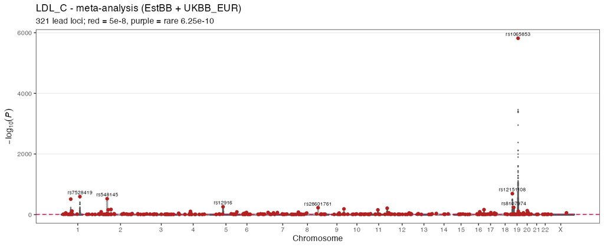

## 4.1 MCQ — Lead variants

**Step 3 calls lead variants with a frequency-dependent threshold: P < 5×10⁻⁸ for common variants (MAF > 0.1%) but the stricter P < 6.25×10⁻¹⁰ for rare variants. The rare-variant threshold is tightened because:**

- A. Rare variants have larger effect sizes, so they need a higher bar.
- B. There are far more rare-variant tests (~80M), so the standard 5×10⁻⁸ line is anti-conservative and would admit too many false positives.
- C. Rare variants are always artifacts and should be suppressed.
- D. LDSC requires it for the heritability estimate.

*Answer: **B.** The genome-wide 5×10⁻⁸ threshold is calibrated to ~1M independent common-variant tests. Adding ~80M rare-variant tests inflates the multiple-testing burden, so a Bonferroni-style tightening (0.05/8×10⁷) is needed to hold the family-wise error rate.*

**A follow-on on locus definition: this replication defines independent loci by distance (top SNP, then a ±1 Mb exclusion window, iterated) rather than by the paper’s LD-based r²≥0.05 merge. The main scientific limitation of the distance-only rule is:**

- A. It cannot handle more than one chromosome.
- B. A single very strong signal (−log₁₀P ≫ 100) can generate association that extends beyond 2 Mb through LD, so distance clumping may split one true signal into several “independent” loci.
- C. It systematically undercounts loci relative to LD clumping.
- D. It requires an in-sample LD matrix to run.

*Answer: **B.** LD can carry a strong association past a fixed window; the paper’s r²≥0.05 merge exists specifically to stop that “bleeding” and collapse the fragments into one locus. Distance clumping has no way to know two windows tag the same causal variant, so it can over-count. It is the honest choice only when no matched genotype panel is available to compute pairwise r² — which is the case here.*

# 5 Fine-mapping + coding annotation (Step 4)

*SuSiE fine-mapping per locus (MHC excluded), then missense/splice annotation of credible-set variants to nominate a candidate effector gene. **Caveat:** out-of-sample LD may miscalibrate credible sets — interpret set sizes and PIPs with that in mind.*

| trait | gene | chr | ID | POS | ea | oa | pip | z | r2_lead | cs | coverage | pass_filter | most_severe | consequence | impact | is_missense | gene_symbol | is_expected_gene | aa_change | codons | sift_pred | sift_score | polyphen_pred | polyphen_score | biotype | allele_match | is_known_causal | source_file |
| --- | --- | --- | --- | --- | --- | --- | --- | --- | --- | --- | --- | --- | --- | --- | --- | --- | --- | --- | --- | --- | --- | --- | --- | --- | --- | --- | --- | --- |
| LDL_C | PCSK9 | 1 | rs9803730 | 54598773 | A | G | 1 | -1.75980014480915 | 0.042306319225 | 10 | 0.95 | False | non_coding_transcript_exon_variant | intron_variant | MODIFIER | False | ACOT11 | False |  |  |  |  |  |  | protein_coding | ea | False | LDL_C.annot.tsv |
| LDL_C | PCSK9 | 1 | rs541575683 | 54933454 | A | G | 1 | 1.80799491765626 | 0.091778096601 | 3 | 0.95 | False | intron_variant | intron_variant | MODIFIER | False | DHCR24-DT | False |  |  |  |  |  |  | lncRNA | ea | False | LDL_C.annot.tsv |
| LDL_C | PCSK9 | 1 | rs191898211 | 54981236 | A | G | 1 | -8.36455256355766 | 0.00023946324516 | 9 | 0.95 | True | intron_variant | intron_variant | MODIFIER | False | TMEM61 | False |  |  |  |  |  |  | protein_coding | ea | False | LDL_C.annot.tsv |
| LDL_C | PCSK9 | 1 | rs11591147 | 55039974 | T | G | 1 | -48.4568685090653 | 1 | 1 | 0.95 | True | missense_variant | missense_variant | MODERATE | True | PCSK9 | True | R46L | cGt/cTt | tolerated | 0.32 | benign | 0 | protein_coding | ea | True | LDL_C.annot.tsv |
| LDL_C | PCSK9 | 1 | rs563641 | 55058714 | C | T | 1 | 8.49298753194857 | 0.019109468169 | 7 | 0.95 | True | intron_variant | intron_variant | MODIFIER | False | PCSK9 | True |  |  |  |  |  |  | protein_coding | ea | False | LDL_C.annot.tsv |
| LDL_C | PCSK9 | 1 | rs12750160 | 55208327 | T | C | 1 | -20.7699028851317 | 0.142384720921 | 5 | 0.95 | True | intron_variant | intron_variant | MODIFIER | False | USP24 | False |  |  |  |  |  |  | protein_coding | ea | False | LDL_C.annot.tsv |
| LDL_C | PCSK9 | 1 | rs184444574 | 55449104 | G | A | 0.999999995120986 | 1.93906091409544 | 0.058775214096 | 6 | 0.95 | False | intron_variant | intron_variant | MODIFIER | False | LINC01755 | False |  |  |  |  |  |  | lncRNA | ea | False | LDL_C.annot.tsv |
| LDL_C | PCSK9 | 1 | rs11206517 | 55060755 | G | T | 0.99379995108963 | 15.9794623844898 | 0.00038999140324 | 4 | 0.95 | True | intron_variant | intron_variant | MODIFIER | False | PCSK9 | True |  |  |  |  |  |  | protein_coding | ea | False | LDL_C.annot.tsv |
| LDL_C | PCSK9 | 1 | rs146044567 | 54659319 | A | G | 0.988686248130772 | -0.0639445197223559 | 0.021247143696 | 8 | 0.95 | False | intron_variant | intron_variant | MODIFIER | False | MROH7 | False |  |  |  |  |  |  | protein_coding | ea | False | LDL_C.annot.tsv |
| LDL_C | PCSK9 | 1 | rs693668 | 55055436 | A | G | 0.629957337405671 | 24.9556886486786 | 3.0683477889e-06 | 2 | 0.95 | True | intron_variant | intron_variant | MODIFIER | False | PCSK9 | True |  |  |  |  |  |  | protein_coding | ea | False | LDL_C.annot.tsv |

[output cut: 122 more lines]

Only the credible-set variants annotated as **missense** are shown below — these are the coding candidates that fine-mapping nominates as potentially causal. The recovery of textbook LDL coding variants (PCSK9 R46L, APOE C130R) at PIP = 1 is the strongest validation that the pipeline works despite the out-of-sample LD.

| gene_symbol | ID | aa_change | pip | cs | sift_pred | polyphen_pred | is_known_causal |
| --- | --- | --- | --- | --- | --- | --- | --- |
| PCSK9 | rs11591147 | R46L | 1 | 1 | tolerated | benign | True |
| ABCG5 | rs141828689 | R198Q | 1 | 5 | deleterious | probably_damaging | False |
| APOE | rs429358 | C130R | 1 | 7 | tolerated |  | False |
| APOB | rs1367117 | T98I | 0.145038947337568 | 3 | deleterious | benign | False |
| ABCG8 | rs4148217 | T400K | 0.0407494245470542 | 10 | deleterious | benign | False |

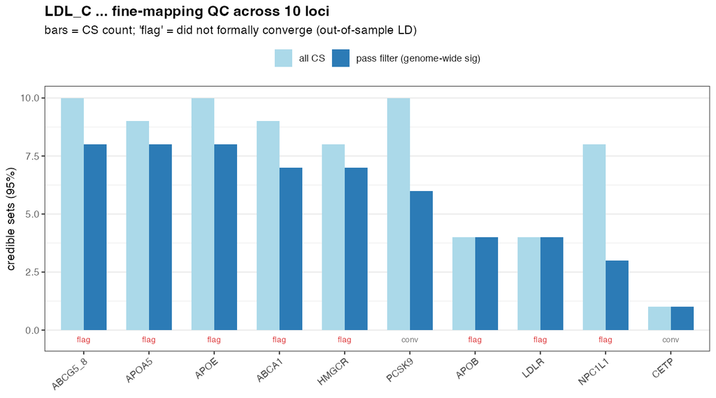

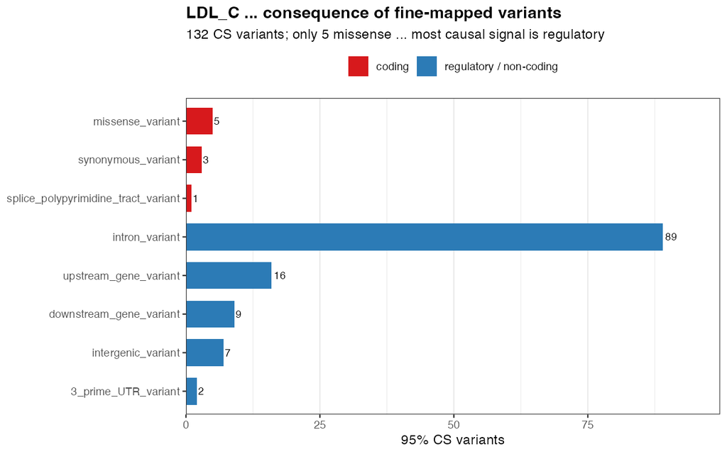

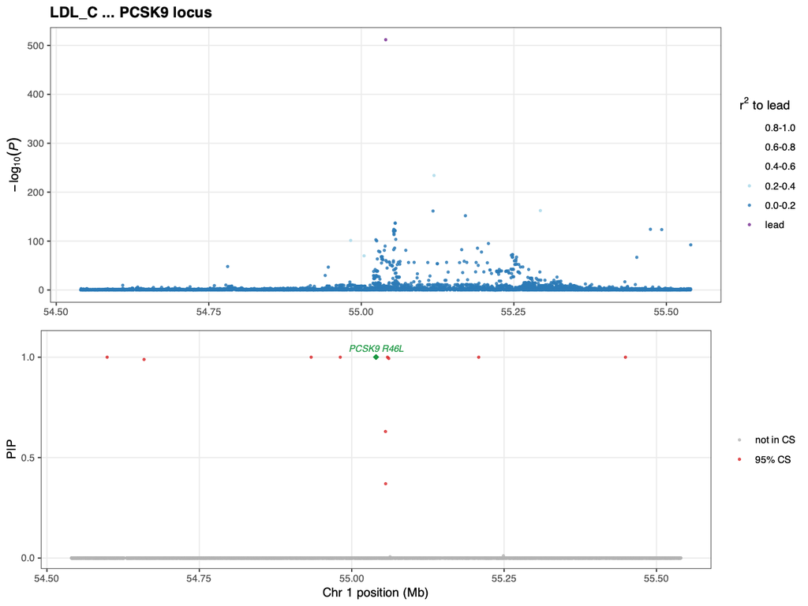

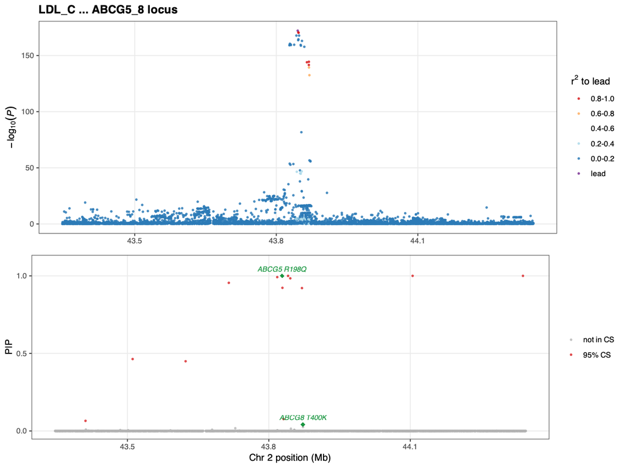

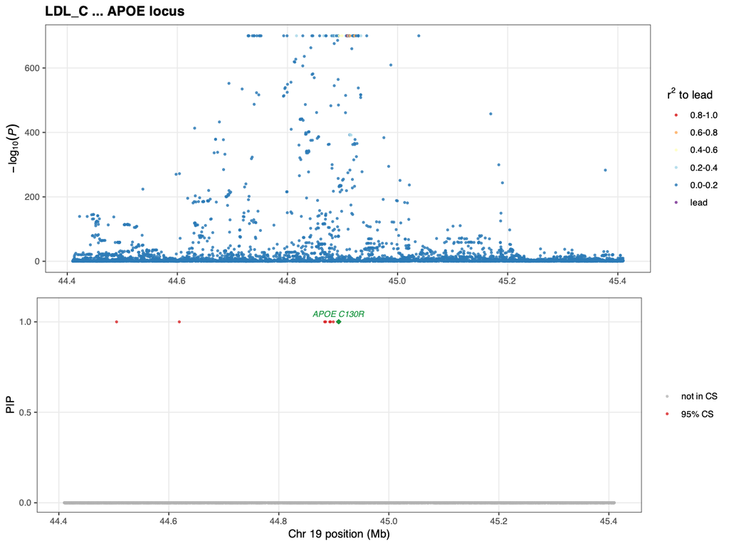

## 5.1 MCQ — Fine-mapping

**The pipeline fine-maps with an out-of-sample 1000G EUR LD reference rather than the in-sample UKBB LD used by the reference paper. The primary risk this introduces to the credible sets is:**

- A. They will always be too small.
- B. LD mismatch can miscalibrate posterior inclusion probabilities and yield spurious or oversized credible sets.
- C. SuSiE cannot run at all without in-sample LD.
- D. It only affects the Manhattan plot, not fine-mapping.

*Answer: **B.** SuSiE-RSS assumes the LD matrix matches the GWAS sample; a mismatched reference distorts PIPs and credible-set membership. In this run the fingerprint is visible in the convergence QC (most loci hit the IBSS iteration cap), which is why an `estimate_s_rss` LD-mismatch diagnostic is reported per locus and `estimate_residual_variance` is fixed to `FALSE` — the documented remedy for out-of-sample LD. This is the single most important caveat of the analysis.*

# 6 Limitations

*Steps 5–7 (colocalization, Mendelian randomization) are in progress and will be added to this report, each with its own MCQ, once their pipeline rules have run.*